# individual1

Ryan Lode

9/27/2020

```r
library(readxl)
library(tidyverse)
```

1.Find the average years of education for the respondents with each political party affiliation. Arrange your output in a meaningful order and print. Describe any patterns you find.

First the GSSdata column names are adjusted to include underscores instead of spaces. Completed education is converted into numeric values and party affiiliation is modified into a factor. Then, party affilation is grouped by and we declare a variable AverageEducation with the mean of the completed education, before displaying it in increasing order.

```r
names(GSSdata) <- c('Gss_year', 'general_happiness', 'Welfare', 'drug_addiction', 'national_health', 'environment','party_affiliation','completed_education','respondent_age','marital_status', 'respondent_id', 'ballot_used')
GSSdata <- GSSdata %>%
  mutate(completed_education = as.numeric(completed_education),
        party_affiliation = as.factor(party_affiliation))

GSSdata %>%
  group_by(party_affiliation) %>%
  summarise(AverageEducation = mean(completed_education,na.rm = TRUE)) %>%
  arrange(AverageEducation)
```

```
## # A tibble: 11 x 2
##    party_affiliation  AverageEducation
##    <fct>                         <dbl>
##  1 Don't know                     10.9
##  2 No answer                      12.3
##  3 Independent                    12.3
##  4 Strong democrat                12.5
##  5 Not str democrat               12.6
##  6 Ind,near dem                   13.2
##  7 Not str republican             13.3
##  8 Ind,near rep                   13.3
##  9 Other party                    13.4
## 10 Strong republican              13.4
## 11 <NA>                          NaN
```

**Analysis:** From the output, we can we see that those whose political party is Strong Republican have highest mean education level. Those who don’t know their party affiliation have the lowest mean education level.

2.Create a single data frame containing records for the better educated respondents in each political party affiliation. A “better educated” respondent is someone who has strictly more years of education than the median in the same party affiliation. Print the structure of the data frame.

```r
betterEducated <- GSSdata %>% group_by(party_affiliation) %>%
  filter(completed_education > median(completed_education, na.rm = TRUE))

betterEducated <-betterEducated[order(betterEducated$completed_education),]

str(betterEducated)
```

```
## tibble [27,840 × 12] (S3: grouped_df/tbl_df/tbl/data.frame)
##  $ Gss_year           : num [1:27840] 1974 1974 1974 1974 1972 ...
##  $ general_happiness  : chr [1:27840] "Very happy" "Very happy" "Pretty happy" "Not too happy" ...
##  $ Welfare            : chr [1:27840] "Too much" "About right" "Don't know" "Too much" ...
##  $ drug_addiction     : chr [1:27840] "About right" "About right" "Too little" "Too little" ...
##  $ national_health    : chr [1:27840] "Too little" "Too little" "Too little" "Too little" ...
##  $ environment        : chr [1:27840] "Too little" "About right" "Too little" "About right" ...
##  $ party_affiliation  : Factor w/ 10 levels "Don't know","Ind,near dem",..: 1 1 1 1 9 6 9 6 4 4 ...
##  $ completed_education: num [1:27840] 12 12 12 12 13 13 13 13 13 13 ...
##  $ respondent_age     : chr [1:27840] "21" "30" "32" "41" ...
##  $ marital_status     : chr [1:27840] "Married" "Married" "Married" "Separated" ...
##  $ respondent_id      : num [1:27840] 33 809 995 1474 11 ...
##  $ ballot_used        : chr [1:27840] "Not applicable" "Not applicable" "Not applicable" "Not applicable" ...
##  - attr(*, "groups")= tibble [10 × 2] (S3: tbl_df/tbl/data.frame)
##   ..$ party_affiliation: Factor w/ 10 levels "Don't know","Ind,near dem",..: 1 2 3 4 5 6 7 8 9 10
##   ..$ .rows            : list<int> [1:10]
##   .. ..$ : int [1:5] 1 2 3 4 22817
##   .. ..$ : int [1:3257] 2706 2714 2722 2731 2735 2746 2754 2771 2783 2807 ...
##   .. ..$ : int [1:2456] 2708 2709 2710 2725 2730 2747 2762 2775 2777 2787 ...
##   .. ..$ : int [1:3852] 9 10 16 20 22 34 51 52 57 58 ...
##   .. ..$ : int [1:148] 209 294 305 467 490 573 1013 1084 1140 1149 ...
##   .. ..$ : int [1:5692] 6 8 11 12 18 19 23 24 25 26 ...
##   .. ..$ : int [1:4322] 2712 2716 2719 2737 2738 2749 2753 2759 2764 2767 ...
##   .. ..$ : int [1:520] 2727 2741 2819 2837 2864 2883 2912 2929 2952 2960 ...
##   .. ..$ : int [1:4537] 5 7 13 14 15 17 21 27 28 35 ...
##   .. ..$ : int [1:3051] 2720 2724 2729 2748 2778 2781 2784 2796 2799 2803 ...
##   .. ..@ ptype: int(0)
##   ..- attr(*, ".drop")= logi TRUE
```

```r
head(betterEducated[,4:8])
```

```
## # A tibble: 6 x 5
## # Groups:   party_affiliation [3]
##   drug_addiction national_health environment  party_affiliation completed_educa…
##   <chr>          <chr>           <chr>        <fct>                        <dbl>
## 1 About right    Too little      Too little   Don't know                      12
## 2 About right    Too little      About right  Don't know                      12
## 3 Too little     Too little      Too little   Don't know                      12
## 4 Too little     Too little      About right  Don't know                      12
## 5 Not applicable Not applicable  Not applica… Strong democrat                 13
## 6 Not applicable Not applicable  Not applica… Not str democrat                13
```

**Analysis :** Examining the tibble, we can see that the completed education years don’t fall below a certain number within political party affiliations.

3.How is the happiness of a respondent related to his/her marriage status? Define that a person is happy if the response to question is “Very happy” or “Pretty happy”.

**Part1:** A new tibble, HappyVsMarriageStatus is created from GSSdata Next, the dataframe is cleaned with na.omit and a series of filter statements.Marital status and party affiliation columns are then converted to factors.

```r
HappyVsMarriageStatus <-GSSdata

HappyVsMarriageStatus = na.omit(HappyVsMarriageStatus)
HappyVsMarriageStatus <- HappyVsMarriageStatus %>%
  filter(!HappyVsMarriageStatus$general_happiness %in% c('No answer','Not applicable','Don\'t know'))
HappyVsMarriageStatus <-HappyVsMarriageStatus %>%
  filter(!HappyVsMarriageStatus$marital_status %in% c('No answer'))
HappyVsMarriageStatus<-HappyVsMarriageStatus %>%
  filter(!HappyVsMarriageStatus$party_affiliation %in% c('Don\'t know', 'No answer'))

maritalStatus <-c('Married','Widowed','Divorced','Separated','Never married')
HappyVsMarriageStatus$marital_status <-factor(HappyVsMarriageStatus$marital_status, levels = maritalStatus)

politicalParty <- c('Other party','Strong democrat', 'Not str democrat','Ind,near dem','Independent','Ind,near rep', 'Not str republican','Strong republican')
HappyVsMarriageStatus$party_affiliation <-factor(HappyVsMarriageStatus$party_affiliation, levels = politicalParty)
```

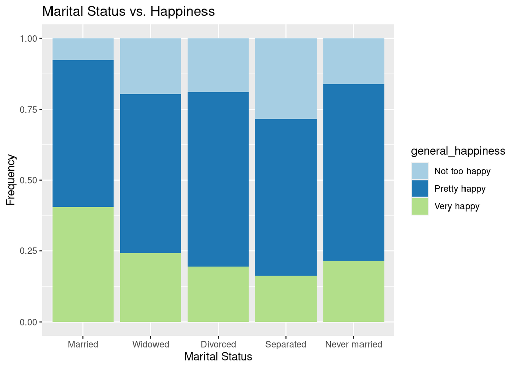

```r
HappyVsMarriageStatus %>%
  group_by(general_happiness, marital_status) %>%
  ggplot(aes(x=marital_status, fill= general_happiness)) +
 geom_bar(position = 'fill') +scale_fill_brewer(palette="Paired") + ggtitle('Marital Status vs. Happiness') +
 ylab('Frequency') + xlab('Marital Status')
```

**Part2:** A new tibble GSSdataVeryHappy was created by calling count on columns marital_status and general_happiness and then grouping by those two columns. A new column indicating the denoting the frequency of each occurrance was generated as well.

```r
GSSdataVeryHappy <-HappyVsMarriageStatus %>%
  count(marital_status, general_happiness) %>%
  group_by(marital_status, general_happiness) %>%
  ungroup

GSSdataVeryHappy <-GSSdataVeryHappy  %>%
  mutate((freq = n /sum(GSSdataVeryHappy$n)) * 100)


GSSdataVeryHappy <-GSSdataVeryHappy %>%
  filter(GSSdataVeryHappy$general_happiness %in% c('Very happy', 'Pretty happy'))

names(GSSdataVeryHappy)[names(GSSdataVeryHappy) == "(freq = n/sum(GSSdataVeryHappy$n)) * 100"] <- 'Relative Frequency'
GSSdataVeryHappy <-GSSdataVeryHappy[order(GSSdataVeryHappy$`Relative Frequency`, decreasing = TRUE), ]
```

```r
head(GSSdataVeryHappy)
```

```
## # A tibble: 6 x 4
##   marital_status general_happiness     n `Relative Frequency`
##   <fct>          <chr>             <int>                <dbl>
## 1 Married        Pretty happy      16386                27.5
## 2 Married        Very happy        12756                21.4
## 3 Never married  Pretty happy       7899                13.3
## 4 Divorced       Pretty happy       4648                 7.80
## 5 Widowed        Pretty happy       3229                 5.42
## 6 Never married  Very happy         2707                 4.55
```

**Analysis:** Analysis: For the general population, of those who reported being either pretty happy’ or ‘very happy’, the majority of them were married. Respondents who were separated from their partners appear to have the lowest percentage of people, among the different categories of marital status, to report being ‘Very Happy’.

4.Does party affiliation affect the relationship you found in the last question?

General Happiness and marital status were grouped by marital status and general happiness and then separated by political party. The resulting plot shows the proportions of people, given a political party and marriage status, who are either very happy, pretty happy, or not too happy.A new tibble ‘Strong Republicans’ was created that focuses solely on people with that particular party affiliation. StrongRepublicans is further filtered to only include married Republicans who listed themselves as either ‘Very happy’ or ’Pretty happy’A relative frequency column was added as well.

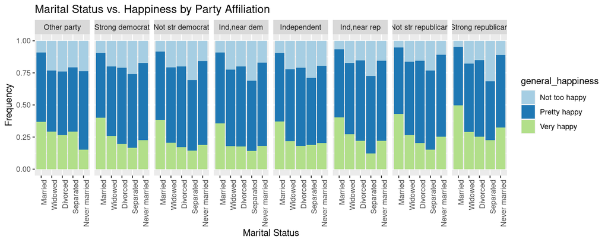

```r
HappyVsMarriageStatus %>%
  group_by(general_happiness, marital_status) %>%
  ggplot(aes(x=marital_status, fill= general_happiness)) + geom_bar(position = 'fill') +scale_fill_brewer(palette="Paired") + theme(axis.text.x = element_text(angle = 90, hjust = 1))+
  facet_grid(~party_affiliation) +ylab('Frequency') + xlab('Marital Status') +
  ggtitle('Marital Status vs. Happiness by Party Affiliation')
```

```r
StrongRepublicans <- HappyVsMarriageStatus %>%
  count(marital_status, general_happiness, party_affiliation) %>%
  group_by(marital_status,general_happiness, party_affiliation) %>%
  ungroup
StrongRepublicans <-StrongRepublicans %>%
  filter(StrongRepublicans$party_affiliation %in% c('Strong republican'))
MarriedRepublicans <-StrongRepublicans %>%
  filter(StrongRepublicans$marital_status %in% c('Married'))

MarriedRepublicans <-MarriedRepublicans %>%
  mutate((freq = n /sum(MarriedRepublicans$n)) * 100) %>%
  ungroup

names(MarriedRepublicans)[names(MarriedRepublicans) == "(freq = n/sum(MarriedRepublicans$n)) * 100"] <- 'Relative Frequency %'

MarriedRepublicans <-MarriedRepublicans[order(MarriedRepublicans$`Relative Frequency %`, decreasing = TRUE),]
```

```r
print(MarriedRepublicans[,])
```

```
## # A tibble: 3 x 5
##   marital_status general_happiness party_affiliation     n `Relative Frequency …
##   <fct>          <chr>             <fct>             <int>                 <dbl>
## 1 Married        Very happy        Strong republican  1774                 49.7
## 2 Married        Pretty happy      Strong republican  1628                 45.7
## 3 Married        Not too happy     Strong republican   164                  4.60
```

**Analysis:** Examining the frequency plot, Strong republicans seem to have an edge in terms of overall happiness. Filtering by Strong republicans and married shows that married republicans are overall, quite happy. In fact, over 95% of married Republicans report being either ‘Very happy’ ‘pretty happy’.

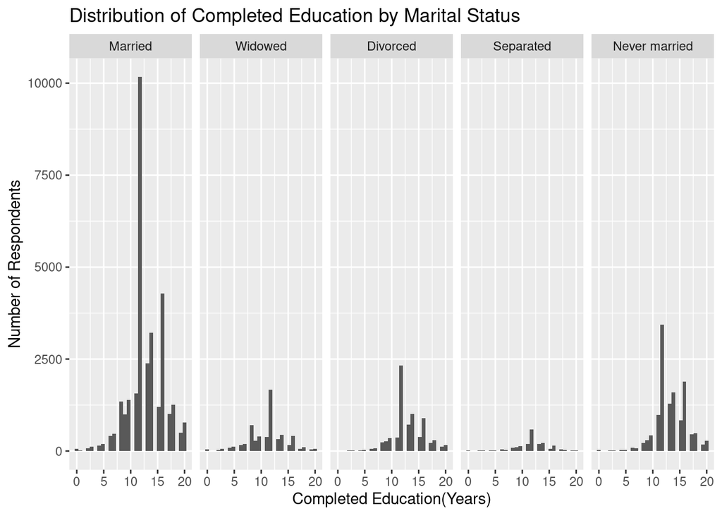

```r
HappyVsMarriageStatus %>%
  group_by(marital_status) %>%
  ggplot(aes(x=completed_education)) +geom_histogram() + facet_grid(~marital_status) +
  ylab('Number of Respondents') + xlab('Completed Education(Years)') + ggtitle('Distribution of Completed Education by Marital Status')
```

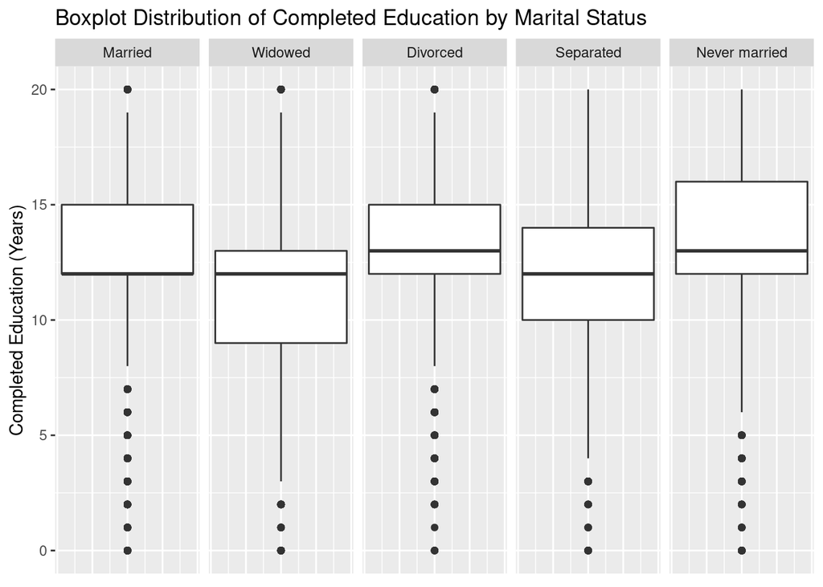

```r
HappyVsMarriageStatus %>%
  group_by(marital_status) %>%
  ggplot(aes(x=completed_education)) +geom_boxplot() + facet_grid(~marital_status,)+ coord_flip()+
  xlab('Completed Education (Years)') + theme(axis.text.x = element_blank(),axis.ticks.x  = element_blank()) +
  ggtitle('Boxplot Distribution of Completed Education by Marital Status')
```

```r
divorcedEducation<-HappyVsMarriageStatus %>%
  filter(marital_status %in% c('Divorced'))

NeverMarriedEduc <-HappyVsMarriageStatus %>%
  filter(marital_status %in% c('Never married'))

marriedEducation <-HappyVsMarriageStatus %>%
  filter(marital_status %in% c('Married'))
```

```r
summary(divorcedEducation$completed_education)
```

```
##    Min. 1st Qu.  Median    Mean 3rd Qu.    Max.
##    0.00   12.00   13.00   13.09   15.00   20.00
```

```r
summary(NeverMarriedEduc$completed_education)
```

```
##    Min. 1st Qu.  Median    Mean 3rd Qu.    Max.
##    0.00   12.00   13.00   13.38   16.00   20.00
```

```r
summary(marriedEducation$completed_education)
```

```
##    Min. 1st Qu.  Median    Mean 3rd Qu.    Max.
##    0.00   12.00   12.00   12.92   15.00   20.00
```

**Analysis:** Analysis:Examining the boxplots and summary statistics, it appears as though divorced respondents had the highest median education level. Married people had a median education level identical to the Q1 value. This is probably due to the very large spike in seen in the histogram. Those who were never married report the highest(tied with those) who were divorced) median education level and the highest Q3 value. Perhaps those who chose not to marry instead focused on continuing their education or research.

6a.How does political party affiliation impact views on the environment? What is the education level distribution of those who think the government is doing too little to protect the environment?

A new tibble environment was created.Then, the environmental column was factorized. Several filter statements were then used to clean the data. A plot showing the proportions environmental views was then generated with ggplot. Finally, a new tibble TooLittle was created that only contained data from those who answered whether the government was doing ‘Too little’ to protect the environment. Summary statistics were then generated on the education level of the respondents.

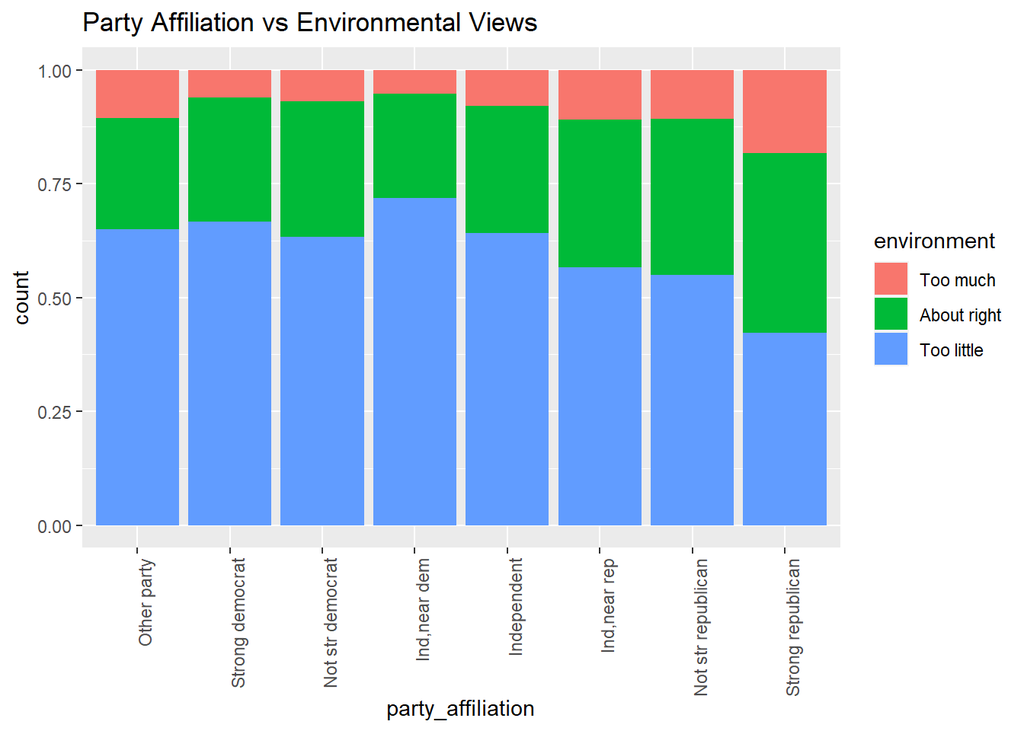

```r
environment <-GSSdata


politicalParty2 <- c('Other party','Strong democrat', 'Not str democrat','Ind,near dem','Independent','Ind,near rep', 'Not str republican','Strong republican')
environment$party_affiliation <-factor(environment$party_affiliation, levels = politicalParty2)

environmentalCare <- c('Too much','About right','Too little')
environment$environment<-factor(environment$environment, levels = environmentalCare)
environment <-environment %>%
  filter(!is.na(environment))

environment <-environment %>%
  filter(!environment %in% c('No answer','Don\'t know','Not applicable', 'NA'))

environment <-environment %>%
  filter(!party_affiliation %in% c('Don\'t know','No answer', 'NA'))

environment = na.omit(environment)

environment <-environment %>%
  filter(!party_affiliation %in% c('Don\'t know','No answer', 'NA'))

environment %>%
  group_by(party_affiliation) %>%
  ggplot(aes(x = party_affiliation, fill = environment)) + geom_bar(position = 'fill') + theme(axis.text.x = element_text(angle = 90, hjust = 1)) +ggtitle('Party Affiliation vs Environmental Views')
```

```r
TooLitte <-environment
```

```r
TooLitte <-TooLitte %>%
  filter(environment %in% c('Too little'))
summary(TooLitte$completed_education)
```

```
##    Min. 1st Qu.  Median    Mean 3rd Qu.    Max.
##    0.00   12.00   12.00   13.09   15.00   20.00
```

**Analysis:** Examining the plot, the proportions of respondents who think the United States is doing too little to protect the environment declines as the views become more conservative. This makes sense given the party’s historical platform. Summary statistics of those who think the government is doing too little to protect the environment, show an IQR of 3 years, but the median was the same as Q1-12 years.

6b.)How does political party affiliation impact views on welfare? What is the mean education level given that the respondents view the government supports welfare too much?

A new tibble, Welfare, was created, then it’s welfare and political party columns were factorized. A series of filter statemnts were then used to clean the data. A staggered bar chart showing the counts of Welfare views by political party was then generated.Finally, a new tibble called TooMuch was generated that focused on those respondents who view that the government is supporting welfare too much. Given that ‘Strong Republicans’ had the highest mean education level, we might expect the mean education level in the TooMuch tibble might be high.

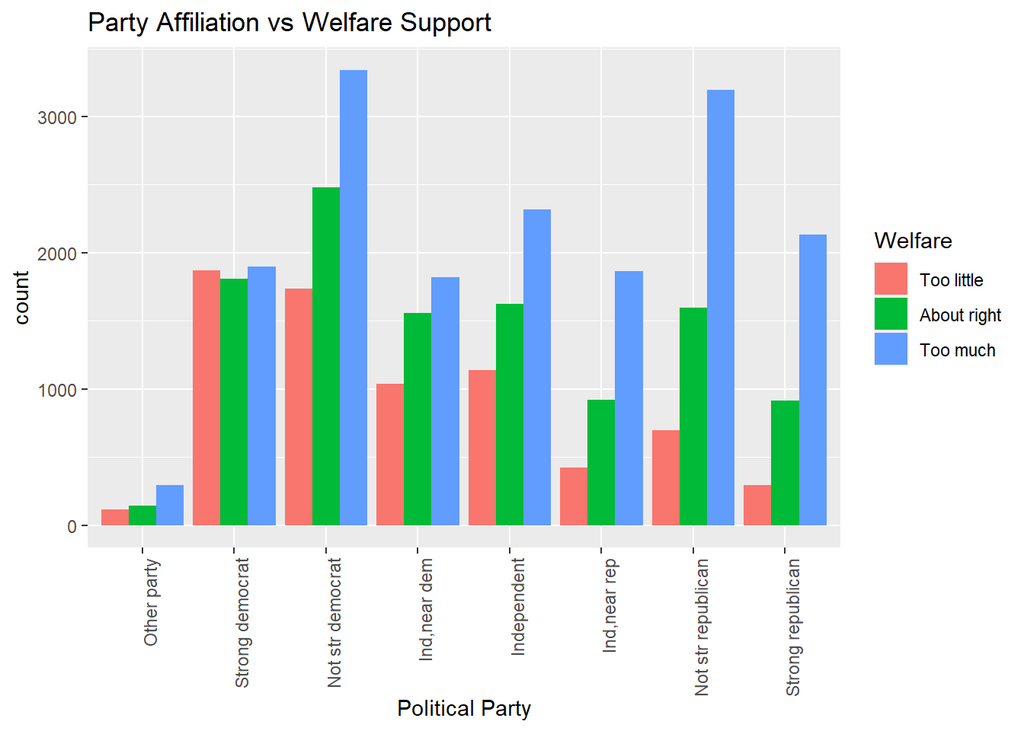

```r
Welfare <-GSSdata



Welfare <-Welfare %>%
  mutate(Welfare = as.factor(Welfare))



GeneralWelfare <- c('Too little','About right','Too much')

Welfare$Welfare<-factor(Welfare$Welfare, levels = GeneralWelfare)

politicalParty3 <- c('Other party','Strong democrat', 'Not str democrat','Ind,near dem','Independent','Ind,near rep', 'Not str republican','Strong republican')
Welfare$party_affiliation <-factor(Welfare$party_affiliation, levels = politicalParty3)

Welfare <-Welfare %>%
  filter(!Welfare %in% c('Don\'t know','No answer', 'NA', 'Not applicable'))

Welfare <-Welfare %>%
  filter(!party_affiliation %in% c('Don\'t know','No answer', 'NA'))

Welfare <-Welfare %>%
  filter(!is.na(Welfare))

Welfare = na.omit(Welfare)

Welfare %>%
  group_by(party_affiliation) %>%
  ggplot(aes(x = party_affiliation, fill = Welfare)) + geom_bar(position = 'dodge') +ggtitle('Party Affiliation vs Welfare Support')+xlab('Political Party') + theme(axis.text.x = element_text(angle = 90, hjust = 1))
```

```r
TooMuch <-Welfare

TooMuch <-TooMuch %>%
  filter(Welfare %in% c('Too much'))


TooMuch <-TooMuch %>%
  mutate(completed_education = as.numeric(completed_education))

TooMuch <-TooMuch %>%
  filter(!is.na(TooMuch))

summary(TooMuch$completed_education)
```

```
##    Min. 1st Qu.  Median    Mean 3rd Qu.    Max.
##    0.00   12.00   12.00   12.82   15.00   20.00
```